# boosting

##### 4.7 Conclusion - Choix du meilleur modele

Nous avons fait *le choix du modèle gbm* pour les raisons suivantes :

Bien qu’il est vrai que la grille de recherche est beaucoup plus large pour le modele GBM, de notre point de vu, une difference de de 5% n’est tout meme pas négligeable.

Enfin, le temps de calcul du gbm en soit n’est pas excessif surtout comparativement à celui de Adaboost.

**Importance des Features :**

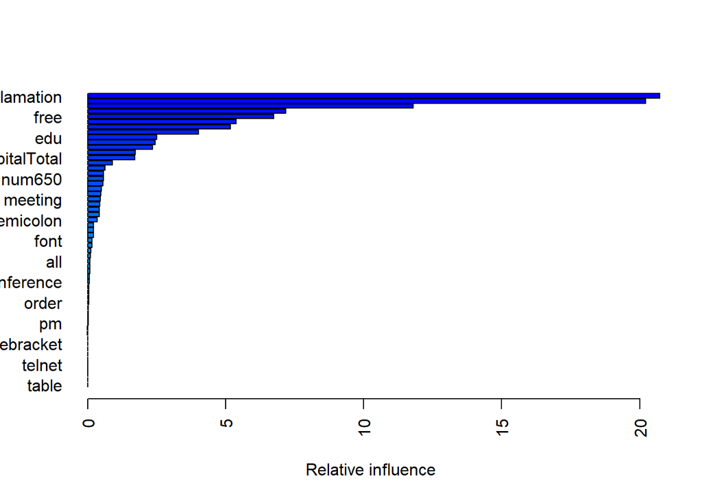

```
##                                 var      rel.inf
## charExclamation     charExclamation 20.724561959
## charDollar               charDollar 20.211094622
## remove                       remove 11.794700601
## hp                               hp  7.182619342
## free                           free  6.738876035
## capitalAve               capitalAve  5.386611638
## your                           your  5.174127639
## capitalLong             capitalLong  4.012945456
## edu                             edu  2.494758318
## george                       george  2.440599219
## money                         money  2.357999723
## our                             our  1.730359371
## capitalTotal           capitalTotal  1.714725170
## you                             you  0.895286686
## internet                   internet  0.632423310
## num1999                     num1999  0.577376053
## num650                       num650  0.576021019
## will                           will  0.550883533
## re                               re  0.494625639
## business                   business  0.467965867
## meeting                     meeting  0.456137975
## email                         email  0.443142103
## receive                     receive  0.427887260
## num000                       num000  0.416624327
## charSemicolon         charSemicolon  0.338811688
## mail                           mail  0.209716750
## over                           over  0.203260671
## charRoundbracket   charRoundbracket  0.201391196
## font                           font  0.152705248
## report                       report  0.151344279
## technology               technology  0.120337258
## hpl                             hpl  0.092399005
## all                             all  0.082113188
## credit                       credit  0.074841937
## project                     project  0.074502323
## address                     address  0.065033469
## conference               conference  0.058870327
## num3d                         num3d  0.045711780
## charHash                   charHash  0.039676711
## make                           make  0.037830053
## order                         order  0.030599851
## data                           data  0.024625397
## num85                         num85  0.022506953
## people                       people  0.016411189
## pm                               pm  0.012862263
## parts                         parts  0.009756301
## addresses                 addresses  0.009728255
## direct                       direct  0.008491320
## charSquarebracket charSquarebracket  0.006434563
## lab                             lab  0.004666512
## cs                               cs  0.003018649
## labs                           labs  0.000000000
## telnet                       telnet  0.000000000
## num857                       num857  0.000000000
## num415                       num415  0.000000000
## original                   original  0.000000000
## table                         table  0.000000000
```

```r
summary(modelFinalGbm,las = 2,angle = 75)
```

On constate que les 3 variables les plus importantes pour la détermination de la catégorie du courrier sont : charExclamation, charDollar et remove. C’est un résultat qui nous parait cohérent.